# Оценка GARCH моделей в R

Подключаем пакет для оценки гарчей в R и прочие удобства:

```r
library("rugarch")
library("forecast")
library("lubridate")
library("xts")
```

В пакете `rugarch` есть встроенный набор данных по индексу `SP500`. Достаём этот набор данных из недр пакета:

```r
data("sp500ret")
```

Посмотрим на начало ряда:

```r
head(sp500ret)
```

```
##                SP500RET
## 1987-03-10  0.008840447
## 1987-03-11 -0.001892734
## 1987-03-12  0.003129678
## 1987-03-13 -0.004577455
## 1987-03-16 -0.005742768
## 1987-03-17  0.014603325
```

Исходный ряд — это `data.frame`. Преобразуем его в `xts` временной ряд. Это немного другой формат хранения данных. Более удобный для временных рядов.

```r
y <- sp500ret$SP500RET
t <- ymd(rownames(sp500ret))
sp500xts <- xts(y, order.by=t)
```

Построим график доходностей и ACF/PACF:

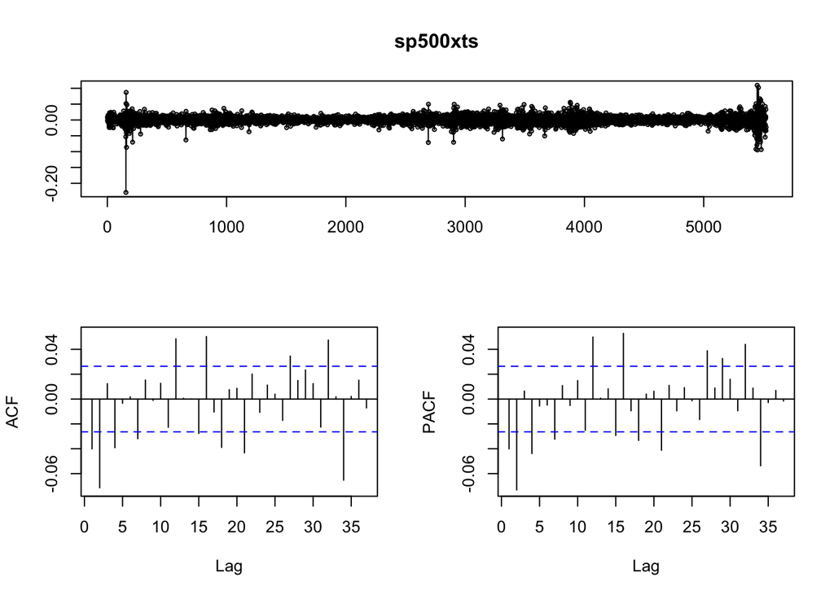

```r
tsdisplay(sp500xts)
```

Пакет `rugarch` оценивает целый зоопарк GARCH моделей. Мы выберем для примера самую простую, ARMA(1,1)-GARCH(1,1) модель.

То есть уравнение для доходности имеет вид: $(y_t-\mu)=\phi_1 (y_{t-1}-\mu) + \theta_1 \varepsilon_{t-1} + \varepsilon_t$

А уравнение для волатильности, $\varepsilon_t = \sigma_t \cdot \nu_t$, имеет вид:

$\sigma^2_t=w + \alpha_1 \varepsilon^2_{t-1}+ \beta_1 \sigma^2_{t-1}$

Сначала указываем желаемую спецификацию, а затем оцениваем.

```r
model <- ugarchspec(
  variance.model = list(garchOrder = c(1, 1)),
  mean.model = list(armaOrder = c(1, 1)))
model_est <- ugarchfit(spec = model,
            data=sp500xts)
```

Смотрим на результаты оценивания:

```r
model_est
```

```
##
## *---------------------------------*
## *          GARCH Model Fit        *
## *---------------------------------*
##
## Conditional Variance Dynamics
## -----------------------------------
## GARCH Model  : sGARCH(1,1)
## Mean Model   : ARFIMA(1,0,1)
## Distribution : norm
##
## Optimal Parameters
## ------------------------------------
##         Estimate  Std. Error  t value Pr(>|t|)
## mu      0.000522    0.000087   5.9878  0.00000
## ar1     0.871332    0.071687  12.1547  0.00000
## ma1    -0.898444    0.064089 -14.0188  0.00000
## omega   0.000001    0.000001   1.3891  0.16481
## alpha1  0.087715    0.013720   6.3930  0.00000
## beta1   0.904954    0.013767  65.7328  0.00000
##
## Robust Standard Errors:
##         Estimate  Std. Error    t value Pr(>|t|)
## mu      0.000522    0.000130   4.014118 0.000060
## ar1     0.871332    0.087565   9.950649 0.000000
## ma1    -0.898444    0.079625 -11.283381 0.000000
## omega   0.000001    0.000014   0.093146 0.925788
## alpha1  0.087715    0.186997   0.469074 0.639016
## beta1   0.904954    0.192511   4.700801 0.000003
##
## LogLikelihood : 17902.41
##
## Information Criteria
## ------------------------------------
##
## Akaike       -6.4807
## Bayes        -6.4735
## Shibata      -6.4807
## Hannan-Quinn -6.4782
##
```

[output cut: 43 more lines]

```
## Negative Sign Bias  2.9467 3.226e-03 ***
## Positive Sign Bias  2.3928 1.675e-02  **
## Joint Effect       28.9717 2.270e-06 ***
##
##
## Adjusted Pearson Goodness-of-Fit Test:
## ------------------------------------
##   group statistic p-value(g-1)
## 1    20     179.0    4.775e-28
## 2    30     187.8    3.641e-25
## 3    40     218.4    8.218e-27
## 4    50     228.1    6.432e-25
##
##
## Elapsed time : 0.85976
```

Можно на каждый из результатов глянуть отдельно. Например, информационные критерии:

```r
infocriteria(model_est)
```

```
##
## Akaike       -6.480683
## Bayes        -6.473495
## Shibata      -6.480686
## Hannan-Quinn -6.478177
```

Можно построить кучу заготовленных графиков. Мы построим два, и настоятельно советуем попробовать `plot(model_est)`:

График автокорреляционной функции самого ряда:

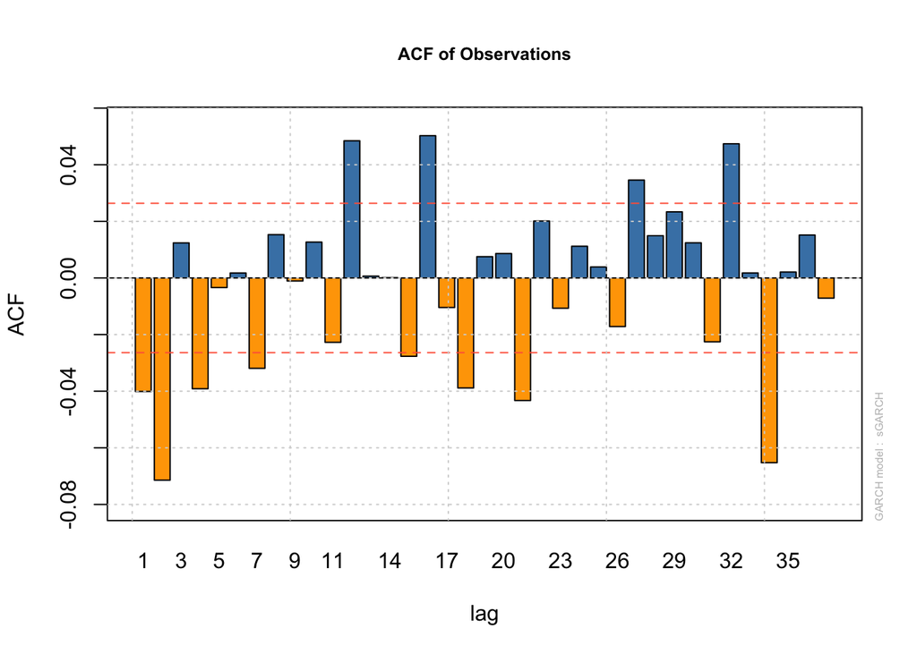

```r
plot(model_est, which=4)
```

Есть и положительные, и отрицательные корреляции, отчасти значимые.

График автокорреляционной функции для квадратов доходностей:

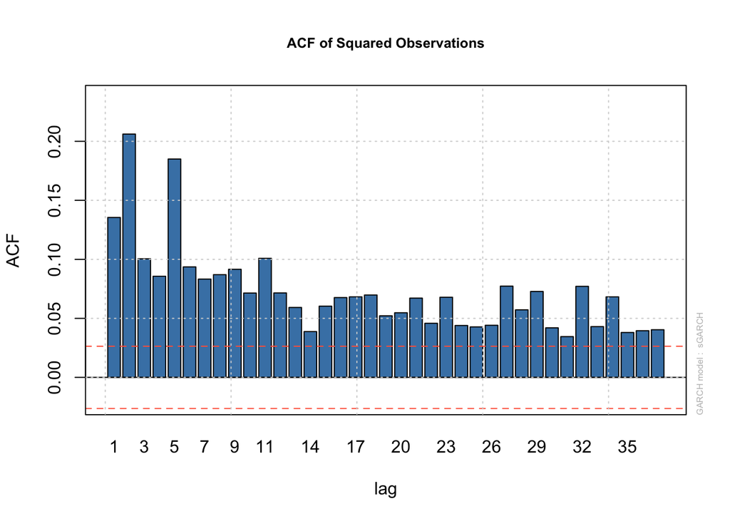

```r
plot(model_est, which=5)
```

Все автокорреляции положительны, первые автокорреляции квадратов значимы.

Прогнозируем на 10 шагов вперёд:

```r
prognoz <- ugarchforecast(model_est)
prognoz
```

```
##
## *------------------------------------*
## *       GARCH Model Forecast         *
## *------------------------------------*
## Model: sGARCH
## Horizon: 10
## Roll Steps: 0
## Out of Sample: 0
##
## 0-roll forecast [T0=2009-01-30]:
##         Series   Sigma
## T+1  0.0016642 0.02480
## T+2  0.0015172 0.02473
## T+3  0.0013892 0.02467
## T+4  0.0012775 0.02460
## T+5  0.0011803 0.02454
## T+6  0.0010956 0.02448
## T+7  0.0010217 0.02442
## T+8  0.0009574 0.02435
## T+9  0.0009013 0.02429
## T+10 0.0008525 0.02423
```